## In-class worksheet 6

**Feb 5, 2015**

## 1. The diamonds dataset

*The `diamonds` dataset provided by ggplot2 provides information about quality and price of 53940 diamonds:*

```r
head(diamonds)
```

```
##   carat       cut color clarity depth table price    x    y    z
## 1  0.23     Ideal     E     SI2  61.5    55   326 3.95 3.98 2.43
## 2  0.21   Premium     E     SI1  59.8    61   326 3.89 3.84 2.31
## 3  0.23      Good     E     VS1  56.9    65   327 4.05 4.07 2.31
## 4  0.29   Premium     I     VS2  62.4    58   334 4.20 4.23 2.63
## 5  0.31      Good     J     SI2  63.3    58   335 4.34 4.35 2.75
## 6  0.24 Very Good     J    VVS2  62.8    57   336 3.94 3.96 2.48
```

*Make a table that contains the median price for each combination of `cut`, `color`, and `clarity`, and arrange the final table in descending order of median price (i) within given groups of `cut` and `color`, and (ii) globally for the entire table.*

```r
diamonds %>% group_by( cut, color, clarity ) %>%
  summarize(med.price = median(price)) %>%
  arrange(desc(med.price))
```

```
## Source: local data frame [276 x 4]
## Groups: cut, color
##
##     cut color clarity med.price
## 1  Fair     D      I1      5538
## 2  Fair     D     VS2      4107
## 3  Fair     D     SI1      3900
## 4  Fair     D     SI2      3473
## 5  Fair     D     VS1      2747
## 6  Fair     D    VVS2      1980
## 7  Fair     D    VVS1      1792
## 8  Fair     D      IF      1440
## 9  Fair     E     SI1      3508
## 10 Fair     E     SI2      3438
## ..  ...   ...     ...       ...
```

This code orders by price for each given combination of `cut` and `color`. This happens because the function `summarize()` removes only one layer of grouping. We can manually remove additional layers of grouping using the function `ungroup()`:

```r
diamonds %>% group_by( cut, color, clarity ) %>%
  summarize(med.price = median(price)) %>%
  ungroup() %>%
  arrange(desc(med.price))
```

```
## Source: local data frame [276 x 4]
##
##          cut color clarity med.price
## 1       Good     D      IF     15081
## 2    Premium     D      IF     10129
## 3      Ideal     J      I1      9454
## 4  Very Good     D      IF      9182
## 5    Premium     J    VVS1      7284
## 6    Premium     J    VVS2      6862
## 7    Premium     J      IF      5844
## 8    Premium     I     VS2      5832
## 9  Very Good     J    VVS2      5665
## 10      Fair     D      I1      5538
## ..       ...   ...     ...       ...
```

As we can see, `ungroup()` removes all grouping. So if we wanted to still group by cut, we’d have to put that back in:

```r
diamonds %>% group_by( cut, color, clarity ) %>%
  summarize(med.price = median(price)) %>%
  ungroup() %>%
  group_by(cut) %>%
  arrange(desc(med.price))
```

```
## Source: local data frame [276 x 4]
## Groups: cut
##
##     cut color clarity med.price
## 1  Fair     D      I1      5538
## 2  Fair     J      I1      5405
## 3  Fair     G     VS2      4838
## 4  Fair     I     SI2      4704
## 5  Fair     I    VVS1      4194
## 6  Fair     H     SI2      4129
## 7  Fair     H    VVS1      4115
## 8  Fair     D     VS2      4107
## 9  Fair     D     SI1      3900
## 10 Fair     H     SI1      3816
## ..  ...   ...     ...       ...
```

*The best cuts of diamonds are “Very Good”, “Premium”, and “Ideal”. Make a table that selects only those diamonds, and find the minimum, median, and maximum price for each cut.*

*Hint: The operator `%in%` is helpful for selecting the diamond cuts.*

```r
diamonds %>% filter(cut %in% c("Very Good", "Premium", "Ideal")) %>%
  group_by(cut) %>%
  summarize(min.price=min(price), med.price=median(price), max.price=max(price))
```

```
## Source: local data frame [3 x 4]
##
##         cut min.price med.price max.price
## 1 Very Good       336      2648     18818
## 2   Premium       326      3185     18823
## 3     Ideal       326      1810     18806
```

*For “Premium” cut diamonds, calculate the mean carat level near the minimum price and near the maximum price. Define “near” as “within 10% of”.*

```r
# We first make a new data frame that only holds premium diamonds
premium.diamonds <- filter(diamonds, cut=="Premium")

# Now we calculate the price boundaries of 10% above min. price and 10% below max. price
cutoff.prices <- premium.diamonds %>%
  summarize(min.cutoff=1.1*min(price), max.cutoff=0.9*max(price))
cutoff.prices
```

```
##   min.cutoff max.cutoff
## 1      358.6      16941
```

```r
# Now we calculate the mean carat levels in the appropriate ranges. First near the minimum price:
premium.diamonds %>% filter(price<cutoff.prices$min.cutoff) %>%
  summarize(mean.carat=mean(carat))
```

```
##   mean.carat
## 1     0.2467
```

```r
# Now near the maximum price:
premium.diamonds %>% filter(price>cutoff.prices$max.cutoff) %>%
  summarize(mean.carat=mean(carat))
```

```
##   mean.carat
## 1      2.075
```

## 2. The msleep dataset

*Verify that the sum of total sleep time and total awake time for all animals in the `msleep` dataset adds up to 24h.*

```r
msleep$sleep_total + msleep$awake
```

```
##  [1] 24.00 24.00 24.00 24.00 24.00 24.00 24.00 24.00 24.00 24.00 24.00
## [12] 24.00 24.00 24.00 24.00 24.00 24.00 24.00 24.00 24.00 24.00 24.00
## [23] 24.00 24.00 24.00 24.00 24.00 24.00 24.00 24.00 24.05 24.00 24.00
## [34] 24.00 24.00 24.00 24.00 24.00 24.00 24.00 24.00 24.00 24.00 24.00
## [45] 24.00 24.00 24.00 24.00 24.00 24.00 24.00 24.00 24.00 24.00 24.00
## [56] 24.00 24.00 24.00 24.00 24.05 24.00 24.00 24.00 24.00 24.00 24.00
## [67] 24.00 24.00 24.00 24.00 24.00 24.00 24.00 24.00 24.00 24.00 24.00
## [78] 24.00 24.00 24.00 24.00 24.00 24.00
```

*For carnivores only, make a plot of the percent of time each animal is in REM sleep (out of the total sleep time) vs. the animal’s body weight (plotted on a log scale).*

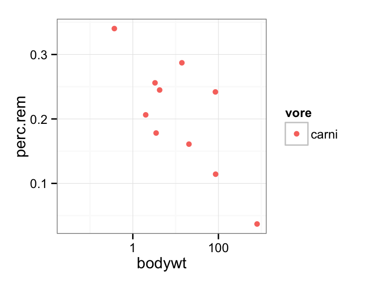

```r
msleep %>% filter(vore=='carni') %>%
  mutate(perc.rem = sleep_rem/sleep_total) -> carni.sleep
ggplot(carni.sleep, aes(x=bodywt, y=perc.rem, color=vore)) + geom_point() + scale_x_log10()
```

*Tally how many vores are awake for at least 18 hours. Hint: use the function `tally()`.*

```r
msleep %>% filter(awake>=18) %>% group_by(vore) %>% tally()
```

```
## Source: local data frame [3 x 2]
##
##    vore  n
## 1 carni  4
## 2 herbi 11
## 3    NA  1
```

*Make a list of all the domesticated species in the `msleep` dataset, in alphabetical order.*

```r
msleep %>% filter(conservation=="domesticated") %>%
  select(name) %>% arrange(name)
```

```
##            name
## 1    Chinchilla
## 2           Cow
## 3           Dog
## 4  Domestic cat
## 5        Donkey
## 6    Guinea pig
## 7         Horse
## 8           Pig
## 9        Rabbit
## 10        Sheep
```

*Identify the top-10 least-awake animals, and list them from least awake to most awake. Explain why this analysis gives you 11 results instead of 10.*

```r
msleep %>% select(name, sleep_total) %>% top_n(10) %>% arrange(desc(sleep_total))
```

```
##                              name sleep_total
## 1                Little brown bat        19.9
## 2                   Big brown bat        19.7
## 3            Thick-tailed opposum        19.4
## 4                 Giant armadillo        18.1
## 5          North American Opossum        18.0
## 6            Long-nosed armadillo        17.4
## 7                      Owl monkey        17.0
## 8          Arctic ground squirrel        16.6
## 9  Golden-mantled ground squirrel        15.9
## 10                          Tiger        15.8
## 11      Eastern american chipmunk        15.8
```

There is a tie. Both the Tiger and the Eastern american chipmunk have a total sleep time of 15.8h, and they are in positions 10 and 11 of the list.

## 3. If this was easy

*Go back to the `diamonds` data set, and using the function `do()`, fit a linear model of price vs. carat separately for each cut. Then make a table that holds the resulting intercepts and slopes.*

```r
diamonds %>% group_by(cut) %>%
  do(lm.result = lm(price ~ carat, data=.)) -> fitted.models
do(fitted.models, data.frame(cut=.$cut,
                             intercept=coef(.$lm.result)[1],
                             slope=coef(.$lm.result)[2]))
```

```
## Source: local data frame [5 x 3]
## Groups: <by row>
##
##         cut intercept slope
## 1      Fair     -1839  5924
## 2      Good     -2423  7480
## 3 Very Good     -2418  7936
## 4   Premium     -2380  7808
## 5     Ideal     -2300  8192
```